# Sentiment analysis of danish newspapers in 1864

# Visualization

Because of the significant changes in Haderslevs publishing amount throughout the years, we create four visualization that shows the publisher and the amount of articles published in each year.

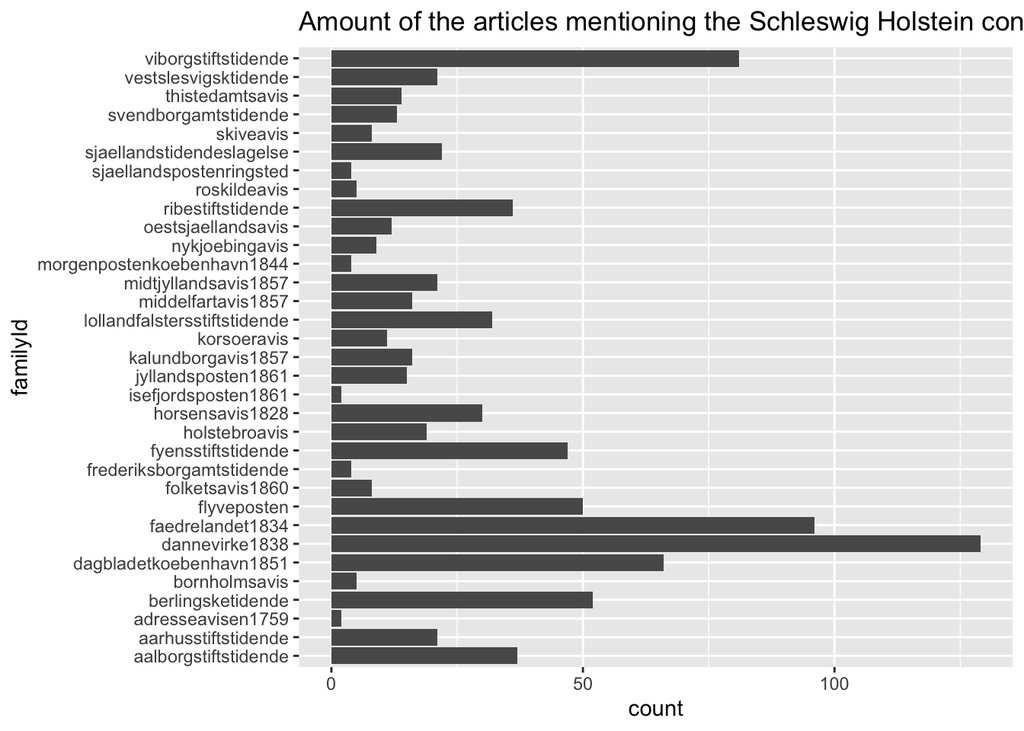

```r
ggplot(all_data_1862, aes(y=familyId))+
  geom_bar()+
  ggtitle("Amount of the articles mentioning the Schleswig Holstein conflict published in 1862, based on the publisher")
```

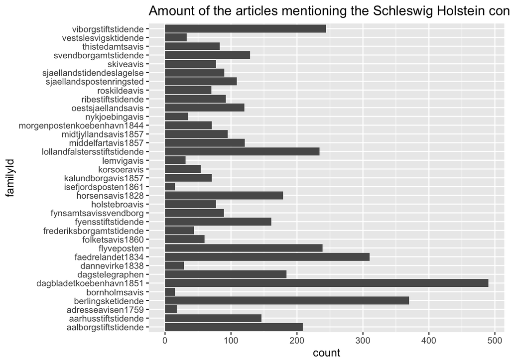

```r
ggplot(all_data, aes(y=familyId))+
  geom_bar()+
  ggtitle("Amount of the articles mentioning the Schleswig Holstein conflict published in 1864, based on the publisher")
```

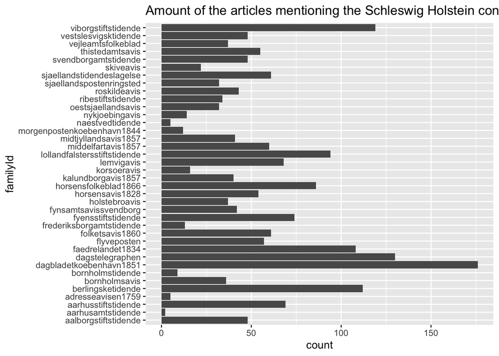

```r
ggplot(all_data_1866, aes(y=familyId))+
  geom_bar()+
  ggtitle("Amount of the articles mentioning the Schleswig Holstein conflict published in 1866, based on the publisher")
```

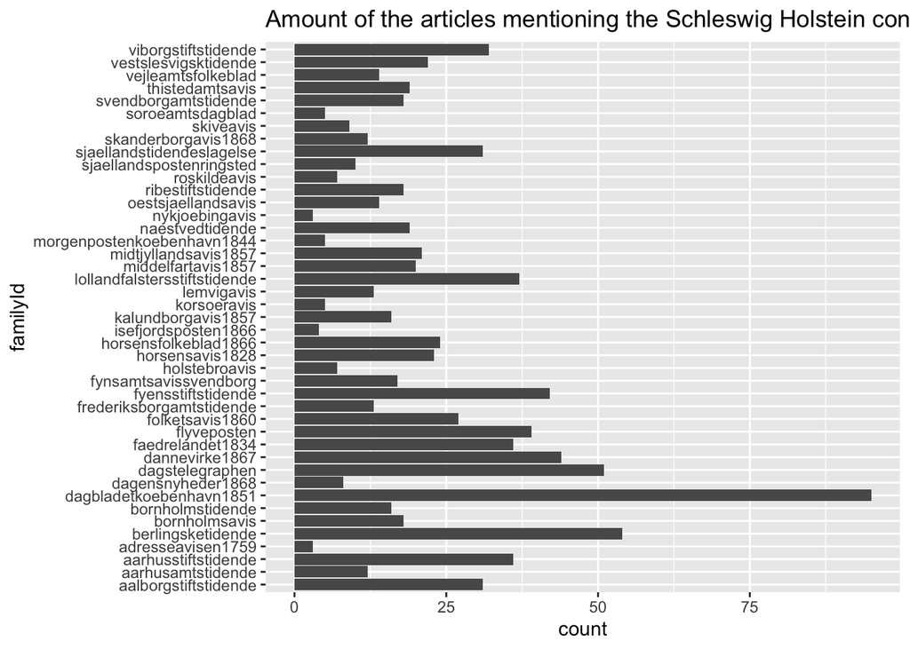

```r
ggplot(all_data_1868, aes(y=familyId))+
  geom_bar()+
  ggtitle("Amount of the articles mentioning the Schleswig Holstein conflict published in 1868, based on the publisher")
```

We know that the Dannevirke 1838 newspaper is a newspaper from Haderslev, so if we look only at the publishing amount of Dannevirke 1838, we see that they suddenly disappear in 1866 and then show up again under the new name Dannevirke 1867 in the dataset from 1868, which could mean that the Dannevirke newspaper, based in Haderslev closed after Haderslev became prussia and then opened up under a new name in 1967. To confirm og deny this theory, we seach a bit on Google and find a article from “Grænseforeningen” about the newspaper Dannevirke, which tells us that prussia closed it after the war in 1684, but that the reopened under the name “Haderslev avis” in 1867, but then decided to change it back to Dannevirke, but this time as Dannevirke 1867, which explains both why there aren´t any publications in 1966 and why there are some in 1868. This is a good example for showing that searching and analysis in R actually can tell us something, that may be valuable to research.